# Water Temperature Regression Analysis

# Regression Analysis for Water Temperature Data

The goal of this analysis is to develop a regression to predict water temperature when data are missing or the time series is incomplete.

Currently this analysis is performed for Feather River and Yuba River. The resulting dataset with predicted values are saved and integrated in the development of a water temperature dataset.

## Data used to build models: Butte Creek

Butte Creek is used to build the regression models because the time series is complete and the data are high quality. * Date range covered is 1999 - 2024

## Overall approach for water temperature regression:

1. Prepare datasets for regression analysis (dataset with no missing data to train and dataset with missing data to predict)
2. Fitting a linear regression models for mean, min, and max temperatures
3. Make predictions for new dataset using the fitted models
4. Combine predictions with actual measurements and handle missing values
5. Visualize the predicted and actual temperature over time to asses model performance trends

## Feather River

### Data Preparation and Approach

1. Pull in gage data from CDEC (GRL will represent the High Flow Channel (HFC) and FRA will represent the Low Flow Channel (LFC):
- GRL (2003-03-05 to 2007-06-01 H; 2020-01-04 to present E): located after Thermalito Afterbay
- FRA (2002-01-01 to present): located between Lake Oroville and Thermalito Afterbay
2. Prepare datasets for regression analysis:
- Dataset with no missing data to train (Butte Creek)
- Dataset with missing data to predict (Feather River)
3. Combine datasets with no missing data, and missing data
4. Identify gaps to predict
5. Use data where there are no missing data for either dataset for regression modeling

### LFC

*Plot of mean temp for Feather River LFC and Butte Creek*

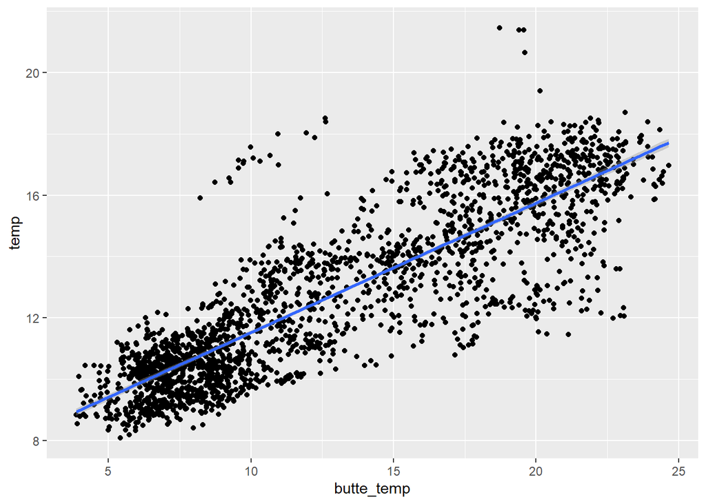

*Plot of min temp for Feather River LFC and Butte Creek*

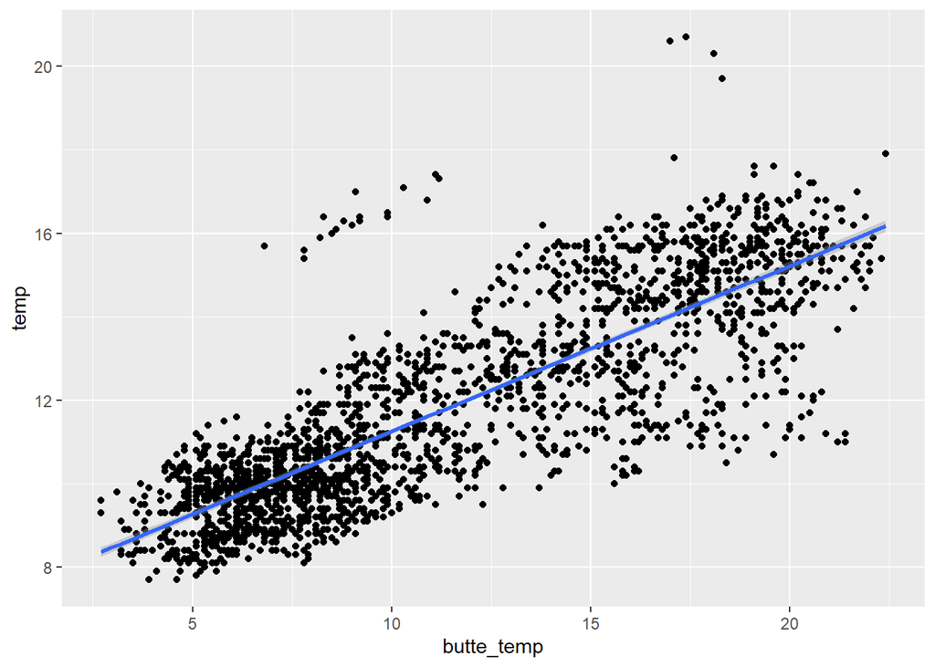

*Plot of max temp for Feather River LFC and Butte Creek*

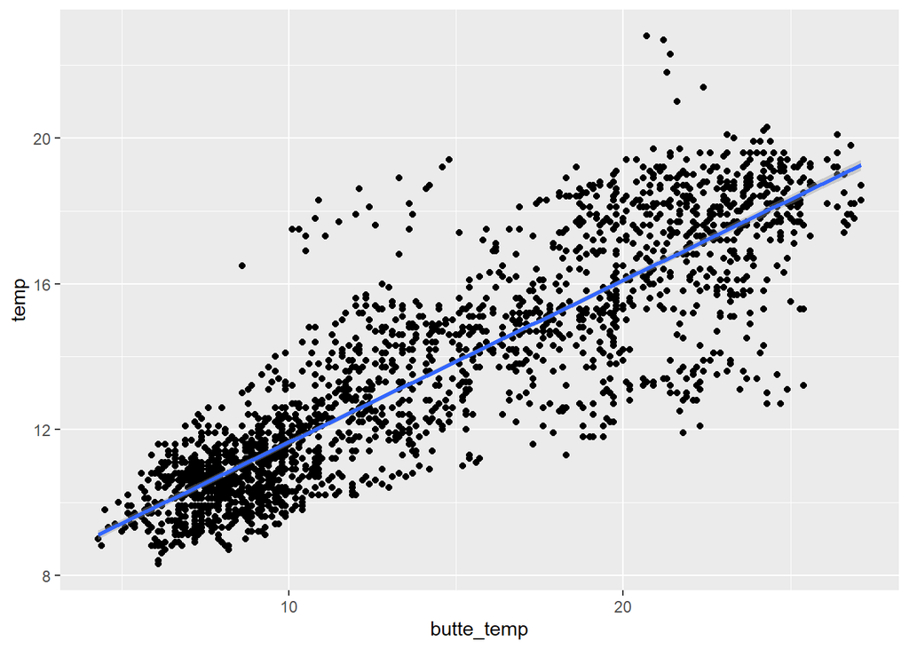

#### Building Mean Regression

- Splitting data
- Building the Model
- Model Summary
- Making predictions
- Evaluating predictions

```r
# LFC regression and predictions

# MEAN Regression
split <-rsample::initial_split(feather_lfc_regression_data_mean, prop = 0.8)
train <- rsample::training(split)
test <- rsample::testing(split)
feather_lfc_mod_mean <- lm(temp ~ date + butte_temp, data = train)
summary(feather_lfc_mod_mean)
```

```
##
## Call:
## lm(formula = temp ~ date + butte_temp, data = train)
##
## Residuals:
##     Min      1Q  Median      3Q     Max
## -4.9153 -0.8438  0.0453  0.7988  5.9112
##
## Coefficients:
##               Estimate Std. Error t value Pr(>|t|)
## (Intercept) -6.077e+00  1.029e+00  -5.908 4.16e-09 ***
## date         7.119e-04  5.461e-05  13.037  < 2e-16 ***
## butte_temp   4.173e-01  6.007e-03  69.461  < 2e-16 ***
## ---
## Signif. codes:  0 '***' 0.001 '**' 0.01 '*' 0.05 '.' 0.1 ' ' 1
##
## Residual standard error: 1.38 on 1701 degrees of freedom
## Multiple R-squared:  0.7518, Adjusted R-squared:  0.7516
## F-statistic:  2577 on 2 and 1701 DF,  p-value: < 2.2e-16
```

```r
test_predict <- predict(feather_lfc_mod_mean, test)
test_predict_df <- test |>
  mutate(predicted = test_predict)
# evaluate predictions - MAPE of 10% is not bad
mean(abs((
  test_predict_df$predicted - test_predict_df$temp
)) / test_predict_df$temp)
```

```
## [1] NA
```

#### Building Min Regression

- Splitting data
- Building the Model
- Model Summary
- Making predictions
- Evaluating predictions

```r
# MIN Regression
split <-rsample::initial_split(feather_lfc_regression_data_min, prop = 0.8)
train <- rsample::training(split)
test <- rsample::testing(split)
feather_lfc_mod_min <- lm(temp ~ date + butte_temp, data = train)
summary(feather_lfc_mod_min)
```

```
##
## Call:
## lm(formula = temp ~ date + butte_temp, data = train)
##
## Residuals:
##     Min      1Q  Median      3Q     Max
## -4.7573 -0.8280  0.0465  0.7597  6.1275
##
## Coefficients:
##               Estimate Std. Error t value Pr(>|t|)
## (Intercept) -4.208e+00  9.891e-01  -4.254 2.22e-05 ***
## date         6.128e-04  5.246e-05  11.683  < 2e-16 ***
## butte_temp   3.930e-01  6.379e-03  61.609  < 2e-16 ***
## ---
## Signif. codes:  0 '***' 0.001 '**' 0.01 '*' 0.05 '.' 0.1 ' ' 1
##
## Residual standard error: 1.332 on 1700 degrees of freedom
##   (1 observation deleted due to missingness)
## Multiple R-squared:  0.7031, Adjusted R-squared:  0.7028
## F-statistic:  2013 on 2 and 1700 DF,  p-value: < 2.2e-16
```

```r
test_predict <- predict(feather_lfc_mod_min, test)
test_predict_df <- test |>
  mutate(predicted = test_predict)
# evaluate predictions - MAPE of 10% is not bad
mean(abs((
  test_predict_df$predicted - test_predict_df$temp
)) / test_predict_df$temp)
```

```
## [1] 0.08575342
```

#### Building Max Regression

- Splitting data
- Building the Model
- Model Summary
- Making predictions
- Evaluating predictions

```r
# MAX Regression
split <-rsample::initial_split(feather_lfc_regression_data_max, prop = 0.8)
train <- rsample::training(split)
test <- rsample::testing(split)
feather_lfc_mod_max <- lm(temp ~ date + butte_temp, data = train)
summary(feather_lfc_mod_max)
```

```
##
## Call:
## lm(formula = temp ~ date + butte_temp, data = train)
##
## Residuals:
##     Min      1Q  Median      3Q     Max
## -5.3742 -0.7990  0.0308  0.8378  6.0325
##
## Coefficients:
##               Estimate Std. Error t value Pr(>|t|)
## (Intercept) -8.066e+00  1.077e+00  -7.491 1.09e-13 ***
## date         8.159e-04  5.716e-05  14.272  < 2e-16 ***
## butte_temp   4.356e-01  5.741e-03  75.874  < 2e-16 ***
## ---
## Signif. codes:  0 '***' 0.001 '**' 0.01 '*' 0.05 '.' 0.1 ' ' 1
##
## Residual standard error: 1.449 on 1700 degrees of freedom
##   (1 observation deleted due to missingness)
## Multiple R-squared:  0.7833, Adjusted R-squared:  0.783
## F-statistic:  3072 on 2 and 1700 DF,  p-value: < 2.2e-16
```

```r
test_predict <- predict(feather_lfc_mod_max, test)
test_predict_df <- test |>
  mutate(predicted = test_predict)
# evaluate predictions - MAPE of 10% is not bad
mean(abs((
  test_predict_df$predicted - test_predict_df$temp
)) / test_predict_df$temp)
```

```
## [1] 0.07658724
```

#### Predictions

- Combine Predictions (mean, min, max dataframes into one)
- Reshape data

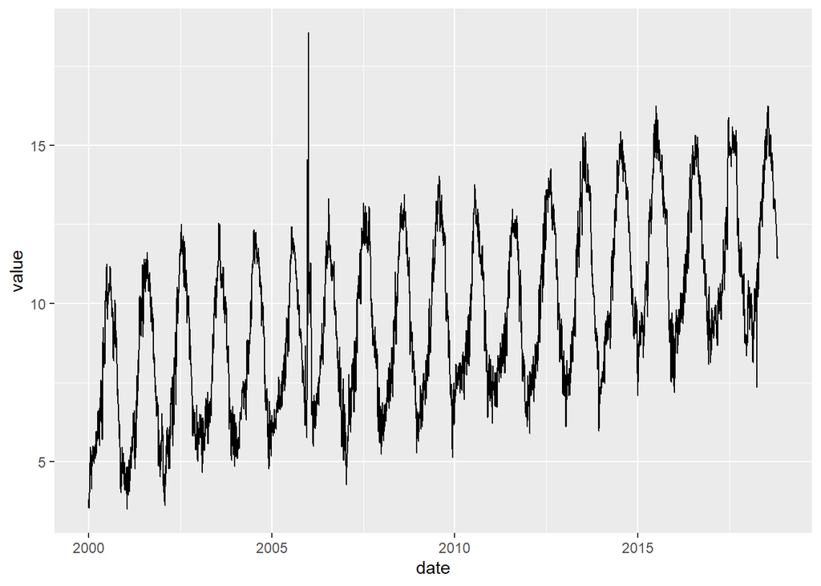

```r
# Predictions
feather_gap_predicted_mean_lfc <- predict(feather_lfc_mod_mean, feather_gap_mean)
feather_lfc_mean_predicted <- feather_gap_mean |>
  mutate(value = feather_gap_predicted_mean_lfc,
         statistic = "mean") |>
  select(date, value, statistic)
ggplot(feather_lfc_mean_predicted, aes(x = date, y = value)) +
  geom_line()
```

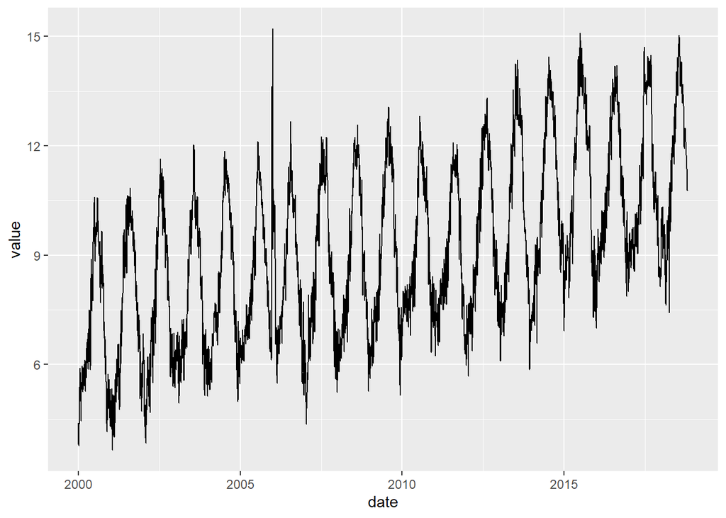

```r
feather_gap_predicted_min_lfc <- predict(feather_lfc_mod_min, feather_gap_min)
feather_lfc_min_predicted <- feather_gap_min |>
  mutate(value = feather_gap_predicted_min_lfc,
         statistic = "min") |>
  select(date, value, statistic)
ggplot(feather_lfc_min_predicted, aes(x = date, y = value)) +
  geom_line()
```

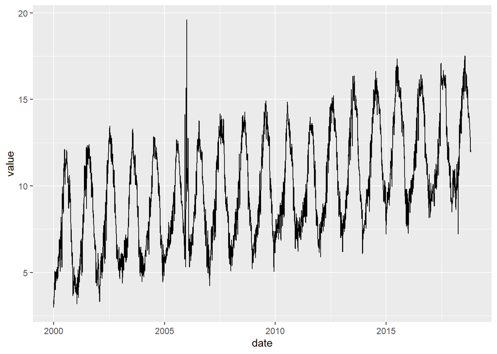

```r
feather_gap_predicted_max_lfc <- predict(feather_lfc_mod_max, feather_gap_max)
feather_lfc_max_predicted <- feather_gap_max |>
  mutate(value = feather_gap_predicted_max_lfc,
         statistic = "max") |>
  select(date, value, statistic)
ggplot(feather_lfc_max_predicted, aes(x = date, y = value)) +
  geom_line()
```

#### Full dataset

- Join with original data (merge combined predictions with the original dataset that includes gage agency and gage number)
- Visualize combined data

```r
feather_gap_lfc <- bind_rows(feather_lfc_max_predicted,
                             feather_lfc_mean_predicted,
                             feather_lfc_min_predicted) |>
  mutate(stream = "feather river",
         site_group = "upper feather lfc") %>%
  pivot_wider(id_cols = c(date, stream, site_group), values_from = "value", names_from = "statistic") |>
  rename(mean_i = mean,
         max_i = max,
         min_i = min) |>
  full_join(feather_lfc_format |>
              pivot_wider(id_cols = c(stream, date, gage_agency, gage_number, site_group), values_from = "value", names_from = "statistic")) |>
  mutate(gage_agency = ifelse(is.na(mean), "interpolated", gage_agency),
         gage_number = ifelse(is.na(mean), "interpolated", gage_number),
         mean = ifelse(is.na(mean), mean_i, mean),
         min = ifelse(is.na(min), min_i, min),
         max = ifelse(is.na(max), max_i, max)) |>
  select(-c(min_i, mean_i, max_i)) |>
  pivot_longer(cols = mean:min, values_to = "value", names_to = "statistic") |>
  group_by(stream, date, statistic, gage_agency, gage_number, site_group) |> glimpse()
```

```
## Rows: 26,871
## Columns: 7
## Groups: stream, date, statistic, gage_agency, gage_number, site_group [26,871]
## $ date        <date> 1999-12-31, 1999-12-31, 1999-12-31, 2000-01-01, 2000-01-0…
## $ stream      <chr> "feather river", "feather river", "feather river", "feathe…
## $ site_group  <chr> "upper feather lfc", "upper feather lfc", "upper feather l…
## $ gage_agency <chr> "interpolated", "interpolated", "interpolated", "interpola…
## $ gage_number <chr> "interpolated", "interpolated", "interpolated", "interpola…
## $ statistic   <chr> "mean", "max", "min", "mean", "max", "min", "mean", "max",…
## $ value       <dbl> 3.725477, 2.963006, 4.393032, 3.795731, 3.399377, 4.197156…
```

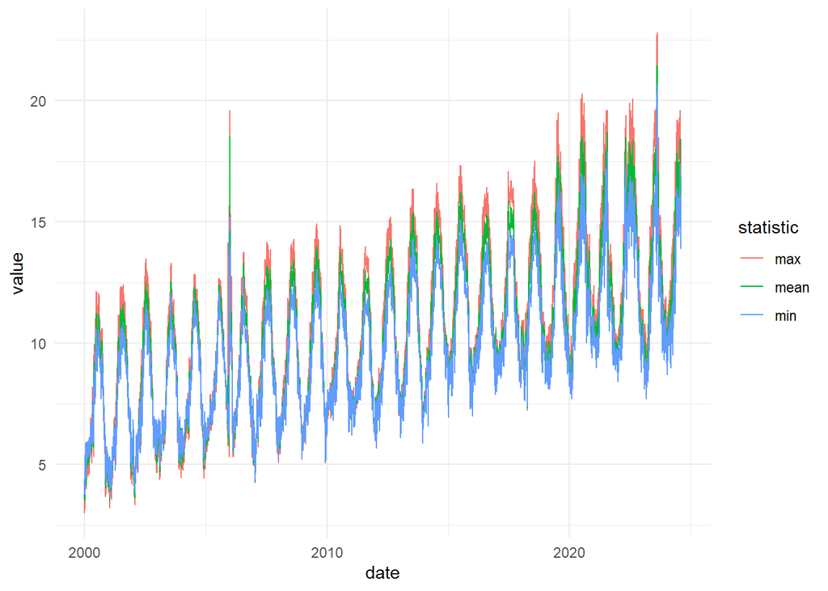

```r
ggplot() +
  geom_line(data = feather_gap_lfc, aes(x = date, y = value, color = statistic)) +
  theme_minimal()
```

### HFC

*Plot of mean temp for Feather River HFC and Butte Creek*

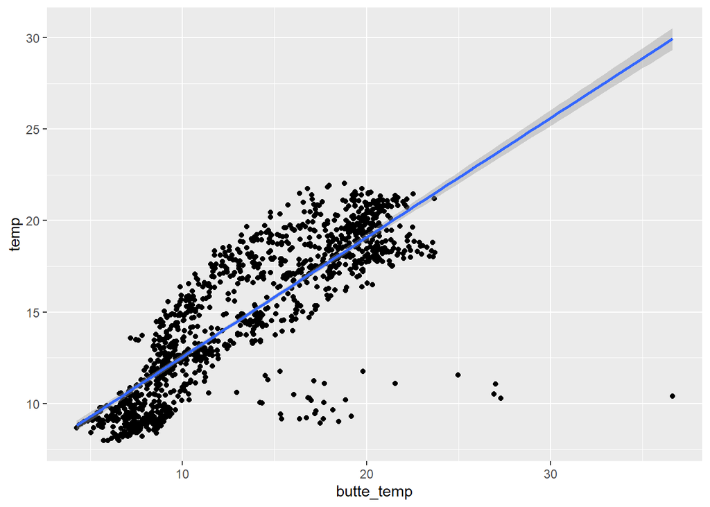

```r
# plot for mean
ggplot(data = feather_hfc_regression_data_mean, aes(x = butte_temp, y = temp)) +
  geom_point() +
  stat_smooth(method = "lm")
```

*Plot of min temp for Feather River HFC and Butte Creek*

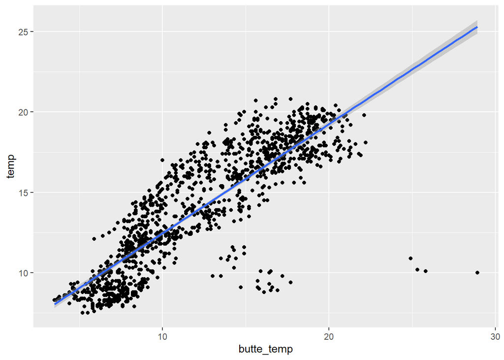

```r
# plot for mean
ggplot(data = feather_hfc_regression_data_min, aes(x = butte_temp, y = temp)) +
  geom_point() +
  stat_smooth(method = "lm")
```

*Plot of max temp for Feather River HFC and Butte Creek*

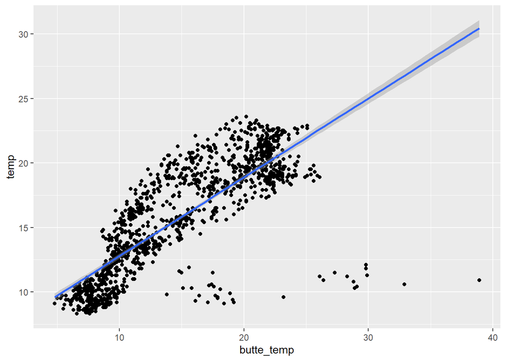

```r
# plot for mean
ggplot(data = feather_hfc_regression_data_max, aes(x = butte_temp, y = temp)) +
  geom_point() +
  stat_smooth(method = "lm")
```

#### Building Mean Regression

- Splitting data
- Building the Model
- Model Summary
- Making predictions
- Evaluating predictions

```r
# HFC regression and predictions

# MEAN Regression
split <-rsample::initial_split(feather_hfc_regression_data_mean, prop = 0.8)
train <- rsample::training(split)
test <- rsample::testing(split)
feather_hfc_mod_mean <- lm(temp ~ date + butte_temp, data = train)
summary(feather_hfc_mod_mean)
```

```
##
## Call:
## lm(formula = temp ~ date + butte_temp, data = train)
##
## Residuals:
##      Min       1Q   Median       3Q      Max
## -13.6413  -1.3340  -0.0864   1.4015   4.9292
##
## Coefficients:
##               Estimate Std. Error t value Pr(>|t|)
## (Intercept) 14.1716918  2.3650132   5.992 2.89e-09 ***
## date        -0.0006583  0.0001861  -3.538 0.000421 ***
## butte_temp   0.6737412  0.0136575  49.331  < 2e-16 ***
## ---
## Signif. codes:  0 '***' 0.001 '**' 0.01 '*' 0.05 '.' 0.1 ' ' 1
##
## Residual standard error: 2.179 on 1000 degrees of freedom
##   (1 observation deleted due to missingness)
## Multiple R-squared:  0.7088, Adjusted R-squared:  0.7082
## F-statistic:  1217 on 2 and 1000 DF,  p-value: < 2.2e-16
```

```r
test_predict <- predict(feather_hfc_mod_mean, test)
test_predict_df <- test |>
  mutate(predicted = test_predict)
# evaluate predictions - MAPE of 10% is not bad
mean(abs((
  test_predict_df$predicted - test_predict_df$temp
)) / test_predict_df$temp)
```

```
## [1] 0.1216612
```

#### Building Min Regression

- Splitting data
- Building the Model
- Model Summary
- Making predictions
- Evaluating predictions

```r
# MIN Regression
split <-rsample::initial_split(feather_hfc_regression_data_min, prop = 0.8)
train <- rsample::training(split)
test <- rsample::testing(split)
feather_hfc_mod_min <- lm(temp ~ date + butte_temp, data = train)
summary(feather_hfc_mod_min)
```

```
##
## Call:
## lm(formula = temp ~ date + butte_temp, data = train)
##
## Residuals:
##     Min      1Q  Median      3Q     Max
## -15.160  -1.137   0.030   1.225   4.374
##
## Coefficients:
##               Estimate Std. Error t value Pr(>|t|)
## (Intercept) 14.7554383  2.1514921   6.858 1.22e-11 ***
## date        -0.0007161  0.0001691  -4.234 2.51e-05 ***
## butte_temp   0.6858181  0.0135157  50.742  < 2e-16 ***
## ---
## Signif. codes:  0 '***' 0.001 '**' 0.01 '*' 0.05 '.' 0.1 ' ' 1
##
## Residual standard error: 1.966 on 1001 degrees of freedom
## Multiple R-squared:  0.7201, Adjusted R-squared:  0.7195
## F-statistic:  1287 on 2 and 1001 DF,  p-value: < 2.2e-16
```

```r
test_predict <- predict(feather_hfc_mod_min, test)
test_predict_df <- test |>
  mutate(predicted = test_predict)
# evaluate predictions - MAPE of 10% is not bad
mean(abs((
  test_predict_df$predicted - test_predict_df$temp
)) / test_predict_df$temp)
```

```
## [1] NA
```

#### Building Max Regression

- Splitting data
- Building the Model
- Model Summary
- Making predictions
- Evaluating predictions

```r
# MAX Regression
split <-rsample::initial_split(feather_hfc_regression_data_max, prop = 0.8)
train <- rsample::training(split)
test <- rsample::testing(split)
feather_hfc_mod_max <- lm(temp ~ date + butte_temp, data = train)
summary(feather_hfc_mod_max)
```

```
##
## Call:
## lm(formula = temp ~ date + butte_temp, data = train)
##
## Residuals:
##      Min       1Q   Median       3Q      Max
## -19.7869  -1.3886  -0.1934   1.6248   5.7004
##
## Coefficients:
##               Estimate Std. Error t value Pr(>|t|)
## (Intercept) 16.4344099  2.7369846   6.005 2.68e-09 ***
## date        -0.0007920  0.0002151  -3.681 0.000245 ***
## butte_temp   0.6340690  0.0141420  44.836  < 2e-16 ***
## ---
## Signif. codes:  0 '***' 0.001 '**' 0.01 '*' 0.05 '.' 0.1 ' ' 1
##
## Residual standard error: 2.531 on 1000 degrees of freedom
##   (1 observation deleted due to missingness)
## Multiple R-squared:  0.6678, Adjusted R-squared:  0.6672
## F-statistic:  1005 on 2 and 1000 DF,  p-value: < 2.2e-16
```

```r
test_predict <- predict(feather_hfc_mod_max, test)
test_predict_df <- test |>
  mutate(predicted = test_predict)
# evaluate predictions - MAPE of 10% is not bad
mean(abs((
  test_predict_df$predicted - test_predict_df$temp
)) / test_predict_df$temp)
```

```
## [1] 0.1396082
```

#### Predictions

- Combine Predictions (mean, min, max dataframes into one)
- Reshape data

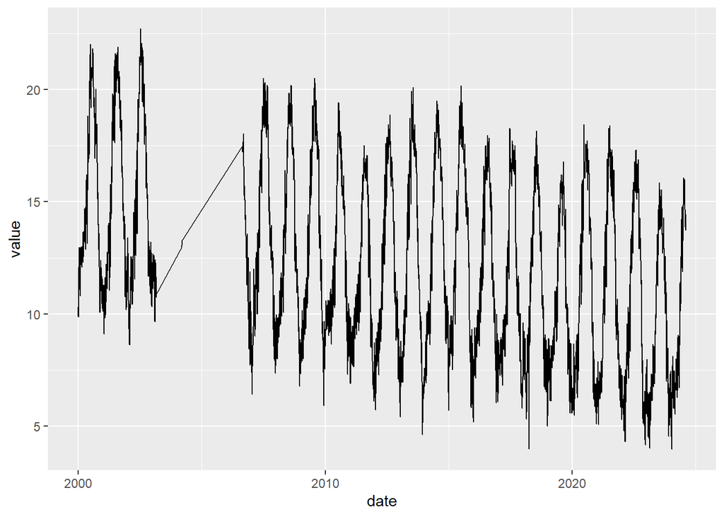

```r
# Predictions
feather_gap_predicted_mean_hfc <- predict(feather_hfc_mod_mean, feather_gap_mean)
feather_hfc_mean_predicted <- feather_gap_mean |>
  mutate(value = feather_gap_predicted_mean_hfc,
         statistic = "mean") |>
  select(date, value, statistic)
ggplot(feather_hfc_mean_predicted, aes(x = date, y = value)) +
  geom_line()
```

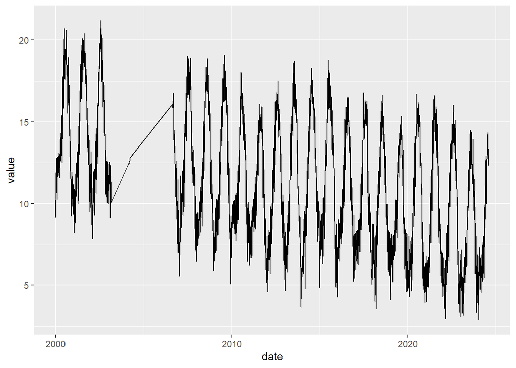

```r
feather_gap_predicted_min_hfc <- predict(feather_hfc_mod_min, feather_gap_min)
feather_hfc_min_predicted <- feather_gap_min |>
  mutate(value = feather_gap_predicted_min_hfc,
         statistic = "min") |>
  select(date, value, statistic)
ggplot(feather_hfc_min_predicted, aes(x = date, y = value)) +
  geom_line()
```

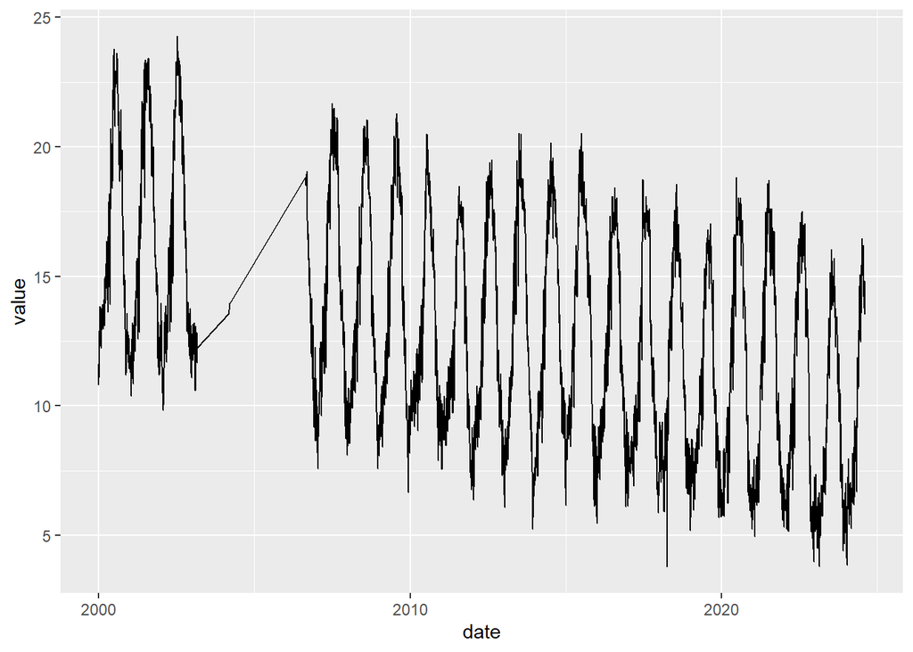

```r
feather_gap_predicted_max_hfc <- predict(feather_hfc_mod_max, feather_gap_max)
feather_hfc_max_predicted <- feather_gap_max |>
  mutate(value = feather_gap_predicted_max_hfc,
         statistic = "max") |>
  select(date, value, statistic)
ggplot(feather_hfc_max_predicted, aes(x = date, y = value)) +
  geom_line()
```

#### Full dataset

- Join with original data (merge combined predictions with the original dataset that includes gage agency and gage number)
- Visualize combined data

```r
feather_gap_hfc <- bind_rows(feather_hfc_max_predicted,
                             feather_hfc_mean_predicted,
                             feather_hfc_min_predicted) |>
  mutate(stream = "feather river",
         site_group = "upper feather hfc") %>%
  pivot_wider(id_cols = c(date, stream, site_group), values_from = "value", names_from = "statistic") |>
  rename(mean_i = mean,
         max_i = max,
         min_i = min) |>
  full_join(feather_hfc_format |>
              pivot_wider(id_cols = c(stream, date, gage_agency, gage_number, site_group), values_from = "value", names_from = "statistic")) |>
  mutate(gage_agency = ifelse(is.na(mean), "interpolated", gage_agency),
         gage_number = ifelse(is.na(mean), "interpolated", gage_number),
         mean = ifelse(is.na(mean), mean_i, mean),
         min = ifelse(is.na(min), min_i, min),
         max = ifelse(is.na(max), max_i, max)) |>
  select(-c(min_i, mean_i, max_i)) |>
  pivot_longer(cols = mean:min, values_to = "value", names_to = "statistic") |>
  group_by(stream, date, statistic, gage_agency, gage_number, site_group) |> glimpse()
```

```
## Rows: 26,907
## Columns: 7
## Groups: stream, date, statistic, gage_agency, gage_number, site_group [26,907]
## $ date        <date> 1999-12-31, 1999-12-31, 1999-12-31, 2000-01-01, 2000-01-0…
## $ stream      <chr> "feather river", "feather river", "feather river", "feathe…
## $ site_group  <chr> "upper feather hfc", "upper feather hfc", "upper feather h…
## $ gage_agency <chr> "interpolated", "interpolated", "interpolated", "interpola…
## $ gage_number <chr> "interpolated", "interpolated", "interpolated", "interpola…
## $ statistic   <chr> "mean", "max", "min", "mean", "max", "min", "mean", "max",…
## $ value       <dbl> 10.193049, 10.801146, 10.201280, 10.304681, 11.434423, 9.8…
```

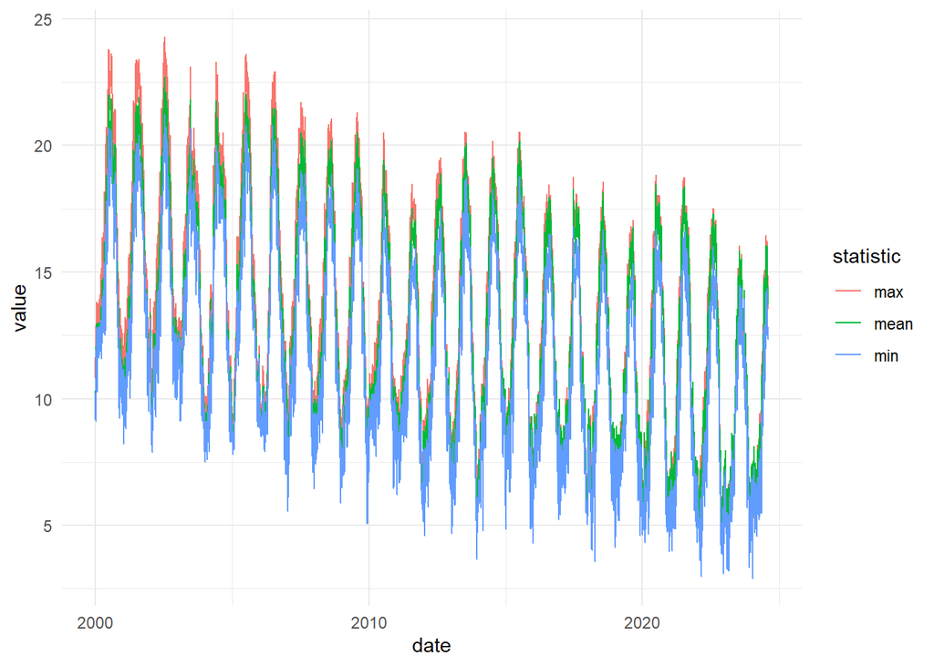

```r
ggplot() +
  geom_line(data = feather_gap_hfc, aes(x = date, y = value, color = statistic)) +
  theme_minimal()
```

## Yuba River

### Data Prepartion and Approach

1. Pull in gage data from YR7 CDEC gage, however, this only contains data from 2020 onwards. Temperature data collected along with RST data was originally used to fill the gap prior to 2020; however, due to inconsistencies in these data sources the resulting predicted mean values were lower than the min values as the RST data only has mean data.
2. Prepare datasets for regression analysis
- Dataset with no missing data to train (Butte Creek)
- Dataset with missing data to predict (Yuba River)
3. Combine datasets with no missing data, and missing data
4. Identify gaps to predict
5. Use data where there are no missing data for either dataset for regression modeling

*Plot of mean temp for Yuba River and Butte Creek*

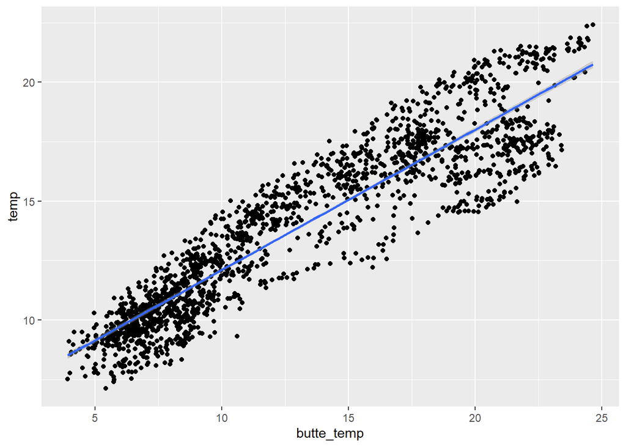

```r
# plot for mean
ggplot(data = yuba_regression_data_mean, aes(x = butte_temp, y = temp)) +
  geom_point() +
  stat_smooth(method = "lm")
```

*Plot of min temp for Yuba River and Butte Creek*

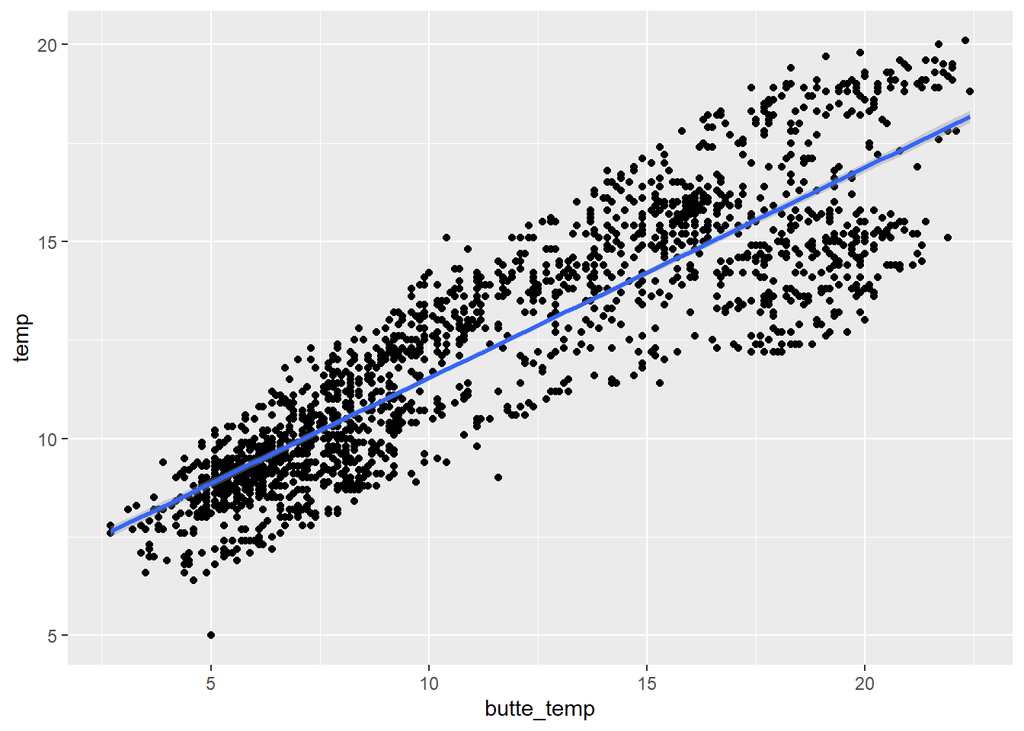

```r
# plot for mean
ggplot(data = yuba_regression_data_min, aes(x = butte_temp, y = temp)) +
  geom_point() +
  stat_smooth(method = "lm")
```

*Plot of max temp for Yuba River and Butte Creek*

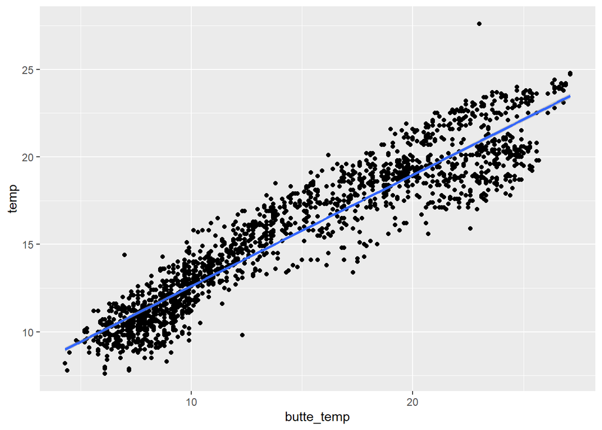

```r
# plot for mean
ggplot(data = yuba_regression_data_max, aes(x = butte_temp, y = temp)) +
  geom_point() +
  stat_smooth(method = "lm")
```

#### Building Mean Regression

- Splitting data
- Building the Model
- Model Summary
- Making predictions
- Evaluating predictions

```r
# MEAN Regression
split <-rsample::initial_split(yuba_regression_data_mean, prop = 0.8)
train <- rsample::training(split)
test <- rsample::testing(split)
yuba_mod_mean <- lm(temp ~ date + butte_temp, data = train)
summary(yuba_mod_mean)
```

```
##
## Call:
## lm(formula = temp ~ date + butte_temp, data = train)
##
## Residuals:
##     Min      1Q  Median      3Q     Max
## -3.9623 -0.8839  0.0012  0.9390  2.9008
##
## Coefficients:
##               Estimate Std. Error t value Pr(>|t|)
## (Intercept)  2.227e+01  1.287e+00   17.31   <2e-16 ***
## date        -8.463e-04  6.745e-05  -12.55   <2e-16 ***
## butte_temp   5.938e-01  6.175e-03   96.17   <2e-16 ***
## ---
## Signif. codes:  0 '***' 0.001 '**' 0.01 '*' 0.05 '.' 0.1 ' ' 1
##
## Residual standard error: 1.327 on 1432 degrees of freedom
## Multiple R-squared:  0.8675, Adjusted R-squared:  0.8673
## F-statistic:  4689 on 2 and 1432 DF,  p-value: < 2.2e-16
```

```r
test_predict <- predict(yuba_mod_mean, test)
test_predict_df <- test |>
  mutate(predicted = test_predict)
# evaluate predictions - MAPE of 10% is not bad
mean(abs((
  test_predict_df$predicted - test_predict_df$temp
)) / test_predict_df$temp)
```

```
## [1] 0.08338709
```

#### Building Min Regression

- Splitting data
- Building the Model
- Model Summary
- Making predictions
- Evaluating predictions

```r
# MIN Regression
split <-rsample::initial_split(yuba_regression_data_min, prop = 0.8)
train <- rsample::training(split)
test <- rsample::testing(split)
yuba_mod_min <- lm(temp ~ date + butte_temp, data = train)
summary(yuba_mod_min)
```

```
##
## Call:
## lm(formula = temp ~ date + butte_temp, data = train)
##
## Residuals:
##     Min      1Q  Median      3Q     Max
## -4.4948 -0.9294 -0.0156  0.9772  3.2129
##
## Coefficients:
##               Estimate Std. Error t value Pr(>|t|)
## (Intercept)  2.284e+01  1.345e+00   16.98   <2e-16 ***
## date        -8.789e-04  7.062e-05  -12.45   <2e-16 ***
## butte_temp   5.432e-01  7.049e-03   77.05   <2e-16 ***
## ---
## Signif. codes:  0 '***' 0.001 '**' 0.01 '*' 0.05 '.' 0.1 ' ' 1
##
## Residual standard error: 1.386 on 1432 degrees of freedom
## Multiple R-squared:  0.8086, Adjusted R-squared:  0.8083
## F-statistic:  3025 on 2 and 1432 DF,  p-value: < 2.2e-16
```

```r
test_predict <- predict(yuba_mod_min, test)
test_predict_df <- test |>
  mutate(predicted = test_predict)
# evaluate predictions - MAPE of 10% is not bad
mean(abs((
  test_predict_df$predicted - test_predict_df$temp
)) / test_predict_df$temp)
```

```
## [1] 0.08646196
```

#### Building Max Regression

- Splitting data
- Building the Model
- Model Summary
- Making predictions
- Evaluating predictions

```r
# MAX Regression
split <-rsample::initial_split(yuba_regression_data_max, prop = 0.8)
train <- rsample::training(split)
test <- rsample::testing(split)
yuba_mod_max <- lm(temp ~ date + butte_temp, data = train)
summary(yuba_mod_max)
```

```
##
## Call:
## lm(formula = temp ~ date + butte_temp, data = train)
##
## Residuals:
##     Min      1Q  Median      3Q     Max
## -4.6258 -0.8501  0.0347  0.9305  3.3897
##
## Coefficients:
##               Estimate Std. Error t value Pr(>|t|)
## (Intercept)  1.833e+01  1.302e+00  14.082   <2e-16 ***
## date        -6.325e-04  6.817e-05  -9.278   <2e-16 ***
## butte_temp   6.345e-01  5.792e-03 109.547   <2e-16 ***
## ---
## Signif. codes:  0 '***' 0.001 '**' 0.01 '*' 0.05 '.' 0.1 ' ' 1
##
## Residual standard error: 1.35 on 1432 degrees of freedom
## Multiple R-squared:  0.8942, Adjusted R-squared:  0.894
## F-statistic:  6050 on 2 and 1432 DF,  p-value: < 2.2e-16
```

```r
test_predict <- predict(yuba_mod_max, test)
test_predict_df <- test |>
  mutate(predicted = test_predict)
# evaluate predictions - MAPE of 10% is not bad
mean(abs((
  test_predict_df$predicted - test_predict_df$temp
)) / test_predict_df$temp)
```

```
## [1] 0.07331728
```

#### Predictions

- Combine Predictions (mean, min, max dataframes into one)
- Reshape data

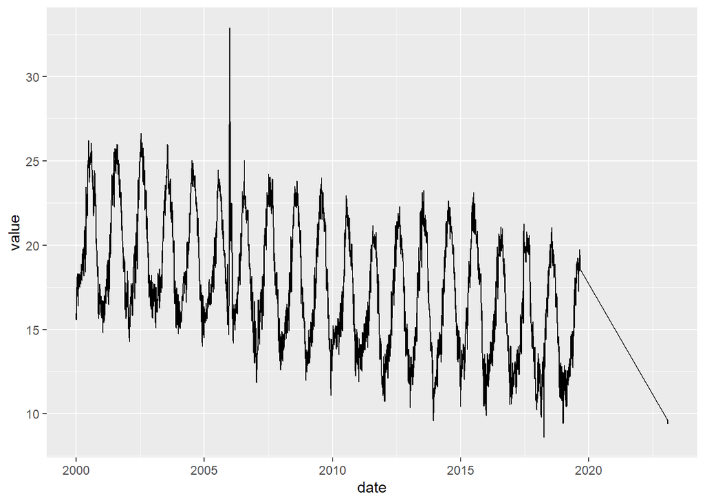

```r
# Predictions
yuba_gap_predicted_mean <- predict(yuba_mod_mean, yuba_gap_mean)
yuba_mean_predicted <- yuba_gap_mean |>
  mutate(value = yuba_gap_predicted_mean,
         statistic = "mean_predicted") |>
  select(date, value, statistic)
ggplot(yuba_mean_predicted, aes(x = date, y = value)) +
  geom_line()
```

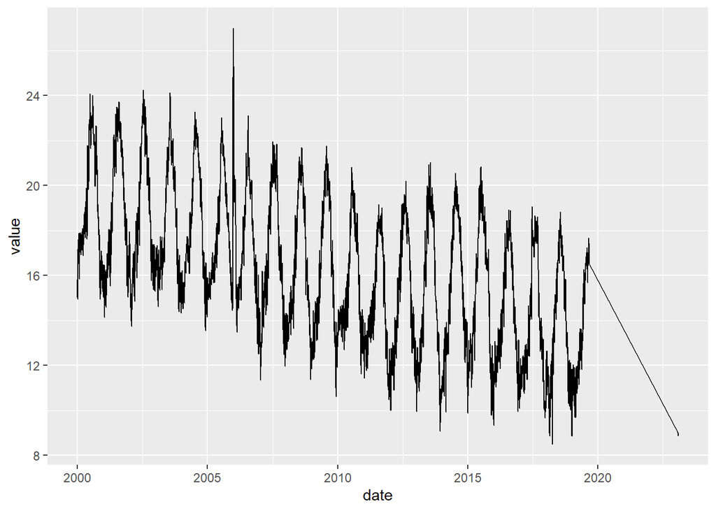

```r
yuba_gap_predicted_min <- predict(yuba_mod_min, yuba_gap_min)
yuba_min_predicted <- yuba_gap_min |>
  mutate(value = yuba_gap_predicted_min,
         statistic = "min_predicted") |>
  select(date, value, statistic)
ggplot(yuba_min_predicted, aes(x = date, y = value)) +
  geom_line()
```

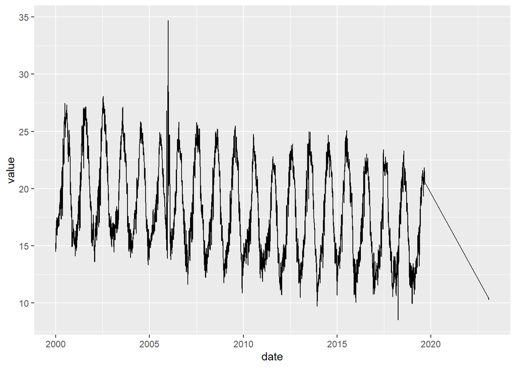

```r
yuba_gap_predicted_max <- predict(yuba_mod_max, yuba_gap_max)
yuba_max_predicted <- yuba_gap_max |>
  mutate(value = yuba_gap_predicted_max,
         statistic = "max_predicted") |>
  select(date, value, statistic)
ggplot(yuba_max_predicted, aes(x = date, y = value)) +
  geom_line()
```

#### Full dataset

- Join with original data (merge combined predictions with the original dataset that includes gage agency and gage number)
- Visualize combined data

```r
yuba_gap <- bind_rows(yuba_max_predicted,
                      yuba_mean_predicted,
                      yuba_min_predicted) |>
  mutate(stream = "yuba river") |>
  pivot_wider(id_cols = c(date, stream), values_from = "value", names_from = "statistic") |>
  full_join(yuba_format |>
              pivot_wider(id_cols = c(stream, date, gage_agency, gage_number), values_from = "value", names_from = "statistic")) |>
  mutate(gage_agency = ifelse(is.na(mean), "interpolated", gage_agency),
         gage_number = ifelse(is.na(mean), "interpolated", gage_number),
         mean = ifelse(is.na(mean), mean_predicted, mean),
         min = ifelse(is.na(min), min_predicted, min),
         max = ifelse(is.na(max), max_predicted, max)) |>
  select(-c(mean_predicted, max_predicted, min_predicted)) |>
    pivot_longer(cols = mean:min, values_to = "value", names_to = "statistic") |>
  group_by(stream, date, statistic, gage_agency, gage_number) |> glimpse()
```

```
## Rows: 26,871
## Columns: 6
## Groups: stream, date, statistic, gage_agency, gage_number [26,871]
## $ date        <date> 1999-12-31, 1999-12-31, 1999-12-31, 2000-01-01, 2000-01-0…
## $ stream      <chr> "yuba river", "yuba river", "yuba river", "yuba river", "y…
## $ gage_agency <chr> "interpolated", "interpolated", "interpolated", "interpola…
## $ gage_number <chr> "interpolated", "interpolated", "interpolated", "interpola…
## $ statistic   <chr> "mean", "max", "min", "mean", "max", "min", "mean", "max",…
## $ value       <dbl> 15.84661, 14.44820, 15.81741, 15.94474, 15.08211, 15.54495…
```

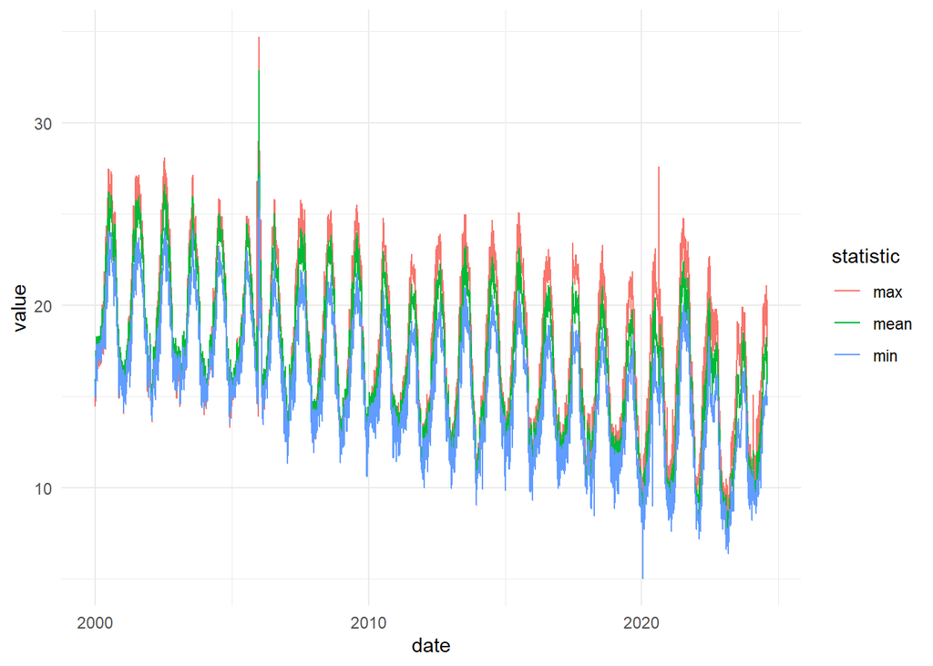

```r
ggplot() +
  geom_line(data = yuba_gap, aes(x = date, y = value, color = statistic)) +
  theme_minimal()
```